# Optimal Treatment Analysis

## Outcome Variable

**Outcome Variable:** ever_wasted

## Predictor Variables

**Intervention Variable:** impfloor

**Adjustment Set:**

- arm
- sex
- W_mage
- meducyrs
- feducyrs
- hhwealth_quart
- hfoodsec
- W_mhtcm
- W_nrooms
- W_nchldlt5
- W_parity
- impsan
- safeh20
- delta_W_mage
- delta_meducyrs
- delta_feducyrs
- delta_hhwealth_quart
- delta_hfoodsec
- delta_W_mhtcm
- delta_W_nrooms
- delta_W_nchldlt5
- delta_W_parity
- delta_impsan
- delta_safeh20

## Stratifying Variables

The analysis was stratified on these variable(s):

- agecat
- studyid
- country

## Data Summary

| agecat | studyid | country | impfloor | ever_wasted | n_cell | n |
| --- | --- | --- | --- | --- | --- | --- |
| 0-24 months (no birth wast) | ki0047075b-MAL-ED | BANGLADESH | 1 | 0 | 173 | 242 |
| 0-24 months (no birth wast) | ki0047075b-MAL-ED | BANGLADESH | 1 | 1 | 50 | 242 |
| 0-24 months (no birth wast) | ki0047075b-MAL-ED | BANGLADESH | 0 | 0 | 12 | 242 |
| 0-24 months (no birth wast) | ki0047075b-MAL-ED | BANGLADESH | 0 | 1 | 7 | 242 |
| 0-24 months (no birth wast) | ki0047075b-MAL-ED | BRAZIL | 1 | 0 | 195 | 209 |
| 0-24 months (no birth wast) | ki0047075b-MAL-ED | BRAZIL | 1 | 1 | 12 | 209 |
| 0-24 months (no birth wast) | ki0047075b-MAL-ED | BRAZIL | 0 | 0 | 2 | 209 |
| 0-24 months (no birth wast) | ki0047075b-MAL-ED | BRAZIL | 0 | 1 | 0 | 209 |
| 0-24 months (no birth wast) | ki0047075b-MAL-ED | INDIA | 1 | 0 | 136 | 231 |
| 0-24 months (no birth wast) | ki0047075b-MAL-ED | INDIA | 1 | 1 | 80 | 231 |
| 0-24 months (no birth wast) | ki0047075b-MAL-ED | INDIA | 0 | 0 | 8 | 231 |
| 0-24 months (no birth wast) | ki0047075b-MAL-ED | INDIA | 0 | 1 | 7 | 231 |
| 0-24 months (no birth wast) | ki0047075b-MAL-ED | NEPAL | 1 | 0 | 86 | 229 |
| 0-24 months (no birth wast) | ki0047075b-MAL-ED | NEPAL | 1 | 1 | 17 | 229 |
| 0-24 months (no birth wast) | ki0047075b-MAL-ED | NEPAL | 0 | 0 | 103 | 229 |
| 0-24 months (no birth wast) | ki0047075b-MAL-ED | NEPAL | 0 | 1 | 23 | 229 |
| 0-24 months (no birth wast) | ki0047075b-MAL-ED | PERU | 1 | 0 | 55 | 272 |
| 0-24 months (no birth wast) | ki0047075b-MAL-ED | PERU | 1 | 1 | 4 | 272 |
| 0-24 months (no birth wast) | ki0047075b-MAL-ED | PERU | 0 | 0 | 197 | 272 |
| 0-24 months (no birth wast) | ki0047075b-MAL-ED | PERU | 0 | 1 | 16 | 272 |
| 0-24 months (no birth wast) | ki0047075b-MAL-ED | SOUTH AFRICA | 1 | 0 | 196 | 257 |
| 0-24 months (no birth wast) | ki0047075b-MAL-ED | SOUTH AFRICA | 1 | 1 | 40 | 257 |
| 0-24 months (no birth wast) | ki0047075b-MAL-ED | SOUTH AFRICA | 0 | 0 | 18 | 257 |
| 0-24 months (no birth wast) | ki0047075b-MAL-ED | SOUTH AFRICA | 0 | 1 | 3 | 257 |
| 0-24 months (no birth wast) | ki0047075b-MAL-ED | TANZANIA, UNITED REPUBLIC OF | 1 | 0 | 13 | 248 |
| 0-24 months (no birth wast) | ki0047075b-MAL-ED | TANZANIA, UNITED REPUBLIC OF | 1 | 1 | 1 | 248 |
| 0-24 months (no birth wast) | ki0047075b-MAL-ED | TANZANIA, UNITED REPUBLIC OF | 0 | 0 | 205 | 248 |
| 0-24 months (no birth wast) | ki0047075b-MAL-ED | TANZANIA, UNITED REPUBLIC OF | 0 | 1 | 29 | 248 |
| 0-24 months (no birth wast) | ki1000108-CMC-V-BCS-2002 | INDIA | 1 | 0 | 145 | 258 |
| 0-24 months (no birth wast) | ki1000108-CMC-V-BCS-2002 | INDIA | 1 | 1 | 113 | 258 |

[output cut: 162 more lines]

The following strata were considered:

- agecat: 0-24 months (no birth wast), studyid: ki0047075b-MAL-ED, country: BANGLADESH
- agecat: 0-24 months (no birth wast), studyid: ki0047075b-MAL-ED, country: BRAZIL
- agecat: 0-24 months (no birth wast), studyid: ki0047075b-MAL-ED, country: INDIA
- agecat: 0-24 months (no birth wast), studyid: ki0047075b-MAL-ED, country: NEPAL
- agecat: 0-24 months (no birth wast), studyid: ki0047075b-MAL-ED, country: PERU
- agecat: 0-24 months (no birth wast), studyid: ki0047075b-MAL-ED, country: SOUTH AFRICA
- agecat: 0-24 months (no birth wast), studyid: ki0047075b-MAL-ED, country: TANZANIA, UNITED REPUBLIC OF
- agecat: 0-24 months (no birth wast), studyid: ki1000108-CMC-V-BCS-2002, country: INDIA
- agecat: 0-24 months (no birth wast), studyid: ki1000108-IRC, country: INDIA
- agecat: 0-24 months (no birth wast), studyid: ki1017093-NIH-Birth, country: BANGLADESH
- agecat: 0-24 months (no birth wast), studyid: ki1017093b-PROVIDE, country: BANGLADESH
- agecat: 0-24 months (no birth wast), studyid: ki1017093c-NIH-Crypto, country: BANGLADESH
- agecat: 0-24 months (no birth wast), studyid: ki1113344-GMS-Nepal, country: NEPAL
- agecat: 0-24 months (no birth wast), studyid: ki1114097-CONTENT, country: PERU
- agecat: 0-24 months (no birth wast), studyid: kiGH5241-JiVitA-3, country: BANGLADESH
- agecat: 0-24 months (no birth wast), studyid: kiGH5241-JiVitA-4, country: BANGLADESH
- agecat: 0-6 months (no birth wast), studyid: ki0047075b-MAL-ED, country: BANGLADESH
- agecat: 0-6 months (no birth wast), studyid: ki0047075b-MAL-ED, country: BRAZIL
- agecat: 0-6 months (no birth wast), studyid: ki0047075b-MAL-ED, country: INDIA
- agecat: 0-6 months (no birth wast), studyid: ki0047075b-MAL-ED, country: NEPAL
- agecat: 0-6 months (no birth wast), studyid: ki0047075b-MAL-ED, country: PERU
- agecat: 0-6 months (no birth wast), studyid: ki0047075b-MAL-ED, country: SOUTH AFRICA
- agecat: 0-6 months (no birth wast), studyid: ki0047075b-MAL-ED, country: TANZANIA, UNITED REPUBLIC OF
- agecat: 0-6 months (no birth wast), studyid: ki1000108-CMC-V-BCS-2002, country: INDIA
- agecat: 0-6 months (no birth wast), studyid: ki1000108-IRC, country: INDIA
- agecat: 0-6 months (no birth wast), studyid: ki1017093-NIH-Birth, country: BANGLADESH
- agecat: 0-6 months (no birth wast), studyid: ki1017093b-PROVIDE, country: BANGLADESH
- agecat: 0-6 months (no birth wast), studyid: ki1017093c-NIH-Crypto, country: BANGLADESH
- agecat: 0-6 months (no birth wast), studyid: ki1113344-GMS-Nepal, country: NEPAL
- agecat: 0-6 months (no birth wast), studyid: ki1114097-CONTENT, country: PERU
- agecat: 0-6 months (no birth wast), studyid: kiGH5241-JiVitA-3, country: BANGLADESH
- agecat: 0-6 months (no birth wast), studyid: kiGH5241-JiVitA-4, country: BANGLADESH
- agecat: 6-24 months, studyid: ki0047075b-MAL-ED, country: BANGLADESH
- agecat: 6-24 months, studyid: ki0047075b-MAL-ED, country: BRAZIL
- agecat: 6-24 months, studyid: ki0047075b-MAL-ED, country: INDIA
- agecat: 6-24 months, studyid: ki0047075b-MAL-ED, country: NEPAL
- agecat: 6-24 months, studyid: ki0047075b-MAL-ED, country: PERU
- agecat: 6-24 months, studyid: ki0047075b-MAL-ED, country: SOUTH AFRICA
- agecat: 6-24 months, studyid: ki0047075b-MAL-ED, country: TANZANIA, UNITED REPUBLIC OF
- agecat: 6-24 months, studyid: ki1000108-CMC-V-BCS-2002, country: INDIA
- agecat: 6-24 months, studyid: ki1000108-IRC, country: INDIA
- agecat: 6-24 months, studyid: ki1017093-NIH-Birth, country: BANGLADESH
- agecat: 6-24 months, studyid: ki1017093b-PROVIDE, country: BANGLADESH
- agecat: 6-24 months, studyid: ki1017093c-NIH-Crypto, country: BANGLADESH
- agecat: 6-24 months, studyid: ki1113344-GMS-Nepal, country: NEPAL
- agecat: 6-24 months, studyid: ki1114097-CONTENT, country: PERU
- agecat: 6-24 months, studyid: kiGH5241-JiVitA-3, country: BANGLADESH
- agecat: 6-24 months, studyid: kiGH5241-JiVitA-4, country: BANGLADESH

### Dropped Strata

Some strata were dropped due to rare outcomes:

- agecat: 0-24 months (no birth wast), studyid: ki0047075b-MAL-ED, country: BRAZIL
- agecat: 0-24 months (no birth wast), studyid: ki0047075b-MAL-ED, country: PERU
- agecat: 0-24 months (no birth wast), studyid: ki0047075b-MAL-ED, country: SOUTH AFRICA
- agecat: 0-24 months (no birth wast), studyid: ki0047075b-MAL-ED, country: TANZANIA, UNITED REPUBLIC OF
- agecat: 0-24 months (no birth wast), studyid: ki1000108-CMC-V-BCS-2002, country: INDIA
- agecat: 0-24 months (no birth wast), studyid: ki1000108-IRC, country: INDIA
- agecat: 0-24 months (no birth wast), studyid: ki1114097-CONTENT, country: PERU
- agecat: 0-6 months (no birth wast), studyid: ki0047075b-MAL-ED, country: BANGLADESH
- agecat: 0-6 months (no birth wast), studyid: ki0047075b-MAL-ED, country: BRAZIL
- agecat: 0-6 months (no birth wast), studyid: ki0047075b-MAL-ED, country: INDIA
- agecat: 0-6 months (no birth wast), studyid: ki0047075b-MAL-ED, country: PERU
- agecat: 0-6 months (no birth wast), studyid: ki0047075b-MAL-ED, country: SOUTH AFRICA
- agecat: 0-6 months (no birth wast), studyid: ki0047075b-MAL-ED, country: TANZANIA, UNITED REPUBLIC OF
- agecat: 0-6 months (no birth wast), studyid: ki1000108-CMC-V-BCS-2002, country: INDIA
- agecat: 0-6 months (no birth wast), studyid: ki1000108-IRC, country: INDIA
- agecat: 0-6 months (no birth wast), studyid: ki1114097-CONTENT, country: PERU
- agecat: 0-6 months (no birth wast), studyid: kiGH5241-JiVitA-4, country: BANGLADESH
- agecat: 6-24 months, studyid: ki0047075b-MAL-ED, country: BRAZIL
- agecat: 6-24 months, studyid: ki0047075b-MAL-ED, country: PERU
- agecat: 6-24 months, studyid: ki0047075b-MAL-ED, country: SOUTH AFRICA
- agecat: 6-24 months, studyid: ki0047075b-MAL-ED, country: TANZANIA, UNITED REPUBLIC OF
- agecat: 6-24 months, studyid: ki1000108-CMC-V-BCS-2002, country: INDIA
- agecat: 6-24 months, studyid: ki1000108-IRC, country: INDIA
- agecat: 6-24 months, studyid: ki1114097-CONTENT, country: PERU

## Methods Detail

We’re interested in the causal parameters $E[Y_a]$ for all values of $a \in \mathcal{A}$. These parameters represent the mean outcome if, possibly contrary to fact, we intervened to set all units to have $A=a$. Under the randomization and positivity assumptions, these are identified by the statistical parameters $\psi_a=E_W[E_{Y|A,W}(Y|A=a,W)]$. In addition, we’re interested in the mean of $Y$, $E[Y]$ under no intervention (the observed mean). We will estimate these parameters by using SuperLearner to fit the relevant likelihood factors – $E_{Y|A,W}(Y|A=a,W)$ and $p(A=a|W)$, and then updating our likelihood fit using a joint TMLE.

For unadjusted analyses ($W=\{\}$), initial likelihoods were estimated using Lrnr_glm to estimate the simple $E(Y|A)$ and Lrnr_mean to estimate $p(A)$. For adjusted analyses, a small library containing Lrnr_glmnet, Lrnr_xgboost, and Lrnr_mean was used.

Having estimated these parameters, we will then use the delta method to estimate relative risks and attributable risks relative to a prespecified baseline level of $A$.

# Results Detail

## Results Plots

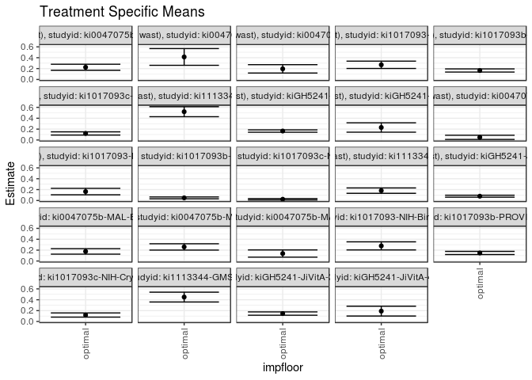

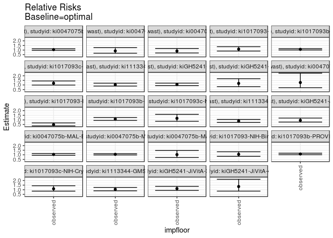

## Results Table

### Parameter: TSM

| agecat | studyid | country | intervention_level | baseline_level | estimate | ci_lower | ci_upper |
| --- | --- | --- | --- | --- | --- | --- | --- |
| 0-24 months (no birth wast) | ki0047075b-MAL-ED | BANGLADESH | optimal | NA | 0.2246249 | 0.1696860 | 0.2795638 |
| 0-24 months (no birth wast) | ki0047075b-MAL-ED | INDIA | optimal | NA | 0.4142892 | 0.2606559 | 0.5679226 |
| 0-24 months (no birth wast) | ki0047075b-MAL-ED | NEPAL | optimal | NA | 0.1953726 | 0.1185692 | 0.2721760 |
| 0-24 months (no birth wast) | ki1017093-NIH-Birth | BANGLADESH | optimal | NA | 0.2698868 | 0.2025396 | 0.3372340 |
| 0-24 months (no birth wast) | ki1017093b-PROVIDE | BANGLADESH | optimal | NA | 0.1650695 | 0.1359987 | 0.1941403 |
| 0-24 months (no birth wast) | ki1017093c-NIH-Crypto | BANGLADESH | optimal | NA | 0.1203275 | 0.0906748 | 0.1499802 |
| 0-24 months (no birth wast) | ki1113344-GMS-Nepal | NEPAL | optimal | NA | 0.5199668 | 0.4281497 | 0.6117838 |
| 0-24 months (no birth wast) | kiGH5241-JiVitA-3 | BANGLADESH | optimal | NA | 0.1644893 | 0.1427843 | 0.1861943 |
| 0-24 months (no birth wast) | kiGH5241-JiVitA-4 | BANGLADESH | optimal | NA | 0.2300151 | 0.1438373 | 0.3161929 |
| 0-6 months (no birth wast) | ki0047075b-MAL-ED | NEPAL | optimal | NA | 0.0487157 | 0.0104826 | 0.0869489 |
| 0-6 months (no birth wast) | ki1017093-NIH-Birth | BANGLADESH | optimal | NA | 0.1639500 | 0.1045301 | 0.2233698 |
| 0-6 months (no birth wast) | ki1017093b-PROVIDE | BANGLADESH | optimal | NA | 0.0482762 | 0.0314069 | 0.0651455 |
| 0-6 months (no birth wast) | ki1017093c-NIH-Crypto | BANGLADESH | optimal | NA | 0.0228425 | 0.0105846 | 0.0351004 |
| 0-6 months (no birth wast) | ki1113344-GMS-Nepal | NEPAL | optimal | NA | 0.1812793 | 0.1318244 | 0.2307342 |
| 0-6 months (no birth wast) | kiGH5241-JiVitA-3 | BANGLADESH | optimal | NA | 0.0788065 | 0.0606927 | 0.0969202 |
| 6-24 months | ki0047075b-MAL-ED | BANGLADESH | optimal | NA | 0.1763824 | 0.1259961 | 0.2267688 |
| 6-24 months | ki0047075b-MAL-ED | INDIA | optimal | NA | 0.2588200 | 0.2007898 | 0.3168502 |
| 6-24 months | ki0047075b-MAL-ED | NEPAL | optimal | NA | 0.1370288 | 0.0706951 | 0.2033626 |
| 6-24 months | ki1017093-NIH-Birth | BANGLADESH | optimal | NA | 0.2779370 | 0.2033474 | 0.3525266 |
| 6-24 months | ki1017093b-PROVIDE | BANGLADESH | optimal | NA | 0.1477892 | 0.1185552 | 0.1770232 |
| 6-24 months | ki1017093c-NIH-Crypto | BANGLADESH | optimal | NA | 0.1191891 | 0.0810344 | 0.1573438 |
| 6-24 months | ki1113344-GMS-Nepal | NEPAL | optimal | NA | 0.4492416 | 0.3589679 | 0.5395153 |
| 6-24 months | kiGH5241-JiVitA-3 | BANGLADESH | optimal | NA | 0.1464331 | 0.1160831 | 0.1767832 |
| 6-24 months | kiGH5241-JiVitA-4 | BANGLADESH | optimal | NA | 0.1909883 | 0.1008362 | 0.2811405 |

### Parameter: E(Y)

| agecat | studyid | country | intervention_level | baseline_level | estimate | ci_lower | ci_upper |
| --- | --- | --- | --- | --- | --- | --- | --- |
| 0-24 months (no birth wast) | ki0047075b-MAL-ED | BANGLADESH | observed | NA | 0.2355372 | 0.1819640 | 0.2891104 |
| 0-24 months (no birth wast) | ki0047075b-MAL-ED | INDIA | observed | NA | 0.3766234 | 0.3140034 | 0.4392434 |
| 0-24 months (no birth wast) | ki0047075b-MAL-ED | NEPAL | observed | NA | 0.1746725 | 0.1253885 | 0.2239565 |
| 0-24 months (no birth wast) | ki1017093-NIH-Birth | BANGLADESH | observed | NA | 0.2974790 | 0.2607158 | 0.3342421 |
| 0-24 months (no birth wast) | ki1017093b-PROVIDE | BANGLADESH | observed | NA | 0.1775837 | 0.1489858 | 0.2061816 |
| 0-24 months (no birth wast) | ki1017093c-NIH-Crypto | BANGLADESH | observed | NA | 0.1432361 | 0.1182149 | 0.1682572 |
| 0-24 months (no birth wast) | ki1113344-GMS-Nepal | NEPAL | observed | NA | 0.5344828 | 0.4890476 | 0.5799179 |
| 0-24 months (no birth wast) | kiGH5241-JiVitA-3 | BANGLADESH | observed | NA | 0.1739633 | 0.1661499 | 0.1817768 |
| 0-24 months (no birth wast) | kiGH5241-JiVitA-4 | BANGLADESH | observed | NA | 0.2693935 | 0.2426940 | 0.2960930 |
| 0-6 months (no birth wast) | ki0047075b-MAL-ED | NEPAL | observed | NA | 0.0616740 | 0.0303107 | 0.0930373 |
| 0-6 months (no birth wast) | ki1017093-NIH-Birth | BANGLADESH | observed | NA | 0.0797227 | 0.0576026 | 0.1018428 |
| 0-6 months (no birth wast) | ki1017093b-PROVIDE | BANGLADESH | observed | NA | 0.0527086 | 0.0359384 | 0.0694789 |
| 0-6 months (no birth wast) | ki1017093c-NIH-Crypto | BANGLADESH | observed | NA | 0.0267023 | 0.0151493 | 0.0382553 |
| 0-6 months (no birth wast) | ki1113344-GMS-Nepal | NEPAL | observed | NA | 0.1588367 | 0.1249135 | 0.1927598 |
| 0-6 months (no birth wast) | kiGH5241-JiVitA-3 | BANGLADESH | observed | NA | 0.0753125 | 0.0700151 | 0.0806099 |
| 6-24 months | ki0047075b-MAL-ED | BANGLADESH | observed | NA | 0.1833333 | 0.1342773 | 0.2323893 |
| 6-24 months | ki0047075b-MAL-ED | INDIA | observed | NA | 0.2723404 | 0.2153029 | 0.3293779 |
| 6-24 months | ki0047075b-MAL-ED | NEPAL | observed | NA | 0.1403509 | 0.0951649 | 0.1855368 |
| 6-24 months | ki1017093-NIH-Birth | BANGLADESH | observed | NA | 0.2936803 | 0.2551592 | 0.3322014 |
| 6-24 months | ki1017093b-PROVIDE | BANGLADESH | observed | NA | 0.1609756 | 0.1319065 | 0.1900447 |
| 6-24 months | ki1017093c-NIH-Crypto | BANGLADESH | observed | NA | 0.1315068 | 0.1069744 | 0.1560393 |
| 6-24 months | ki1113344-GMS-Nepal | NEPAL | observed | NA | 0.4708423 | 0.4253270 | 0.5163576 |
| 6-24 months | kiGH5241-JiVitA-3 | BANGLADESH | observed | NA | 0.1648300 | 0.1556593 | 0.1740008 |
| 6-24 months | kiGH5241-JiVitA-4 | BANGLADESH | observed | NA | 0.2573427 | 0.2311603 | 0.2835250 |

### Parameter: RR

| agecat | studyid | country | intervention_level | baseline_level | estimate | ci_lower | ci_upper |
| --- | --- | --- | --- | --- | --- | --- | --- |
| 0-24 months (no birth wast) | ki0047075b-MAL-ED | BANGLADESH | observed | optimal | 1.0485801 | 0.9668861 | 1.1371766 |
| 0-24 months (no birth wast) | ki0047075b-MAL-ED | INDIA | observed | optimal | 0.9090832 | 0.6545864 | 1.2625257 |
| 0-24 months (no birth wast) | ki0047075b-MAL-ED | NEPAL | observed | optimal | 0.8940480 | 0.6831328 | 1.1700827 |
| 0-24 months (no birth wast) | ki1017093-NIH-Birth | BANGLADESH | observed | optimal | 1.1022361 | 0.8898693 | 1.3652841 |
| 0-24 months (no birth wast) | ki1017093b-PROVIDE | BANGLADESH | observed | optimal | 1.0758118 | 1.0067507 | 1.1496103 |
| 0-24 months (no birth wast) | ki1017093c-NIH-Crypto | BANGLADESH | observed | optimal | 1.1903853 | 0.9904134 | 1.4307330 |
| 0-24 months (no birth wast) | ki1113344-GMS-Nepal | NEPAL | observed | optimal | 1.0279172 | 0.8813543 | 1.1988524 |
| 0-24 months (no birth wast) | kiGH5241-JiVitA-3 | BANGLADESH | observed | optimal | 1.0575965 | 0.9298758 | 1.2028598 |
| 0-24 months (no birth wast) | kiGH5241-JiVitA-4 | BANGLADESH | observed | optimal | 1.1711992 | 0.8168216 | 1.6793235 |
| 0-6 months (no birth wast) | ki0047075b-MAL-ED | NEPAL | observed | optimal | 1.2659975 | 0.7012815 | 2.2854583 |
| 0-6 months (no birth wast) | ki1017093-NIH-Birth | BANGLADESH | observed | optimal | 0.4862624 | 0.3527134 | 0.6703776 |
| 0-6 months (no birth wast) | ki1017093b-PROVIDE | BANGLADESH | observed | optimal | 1.0918133 | 0.9481655 | 1.2572239 |
| 0-6 months (no birth wast) | ki1017093c-NIH-Crypto | BANGLADESH | observed | optimal | 1.1689736 | 0.8517458 | 1.6043511 |
| 0-6 months (no birth wast) | ki1113344-GMS-Nepal | NEPAL | observed | optimal | 0.8761989 | 0.7306953 | 1.0506767 |
| 0-6 months (no birth wast) | kiGH5241-JiVitA-3 | BANGLADESH | observed | optimal | 0.9556636 | 0.7635020 | 1.1961893 |
| 6-24 months | ki0047075b-MAL-ED | BANGLADESH | observed | optimal | 1.0394083 | 0.9471238 | 1.1406846 |
| 6-24 months | ki0047075b-MAL-ED | INDIA | observed | optimal | 1.0522388 | 0.9823693 | 1.1270776 |
| 6-24 months | ki0047075b-MAL-ED | NEPAL | observed | optimal | 1.0242435 | 0.7125975 | 1.4721840 |
| 6-24 months | ki1017093-NIH-Birth | BANGLADESH | observed | optimal | 1.0566435 | 0.8366346 | 1.3345077 |
| 6-24 months | ki1017093b-PROVIDE | BANGLADESH | observed | optimal | 1.0892246 | 1.0098850 | 1.1747973 |
| 6-24 months | ki1017093c-NIH-Crypto | BANGLADESH | observed | optimal | 1.1033466 | 0.8494239 | 1.4331759 |
| 6-24 months | ki1113344-GMS-Nepal | NEPAL | observed | optimal | 1.0480827 | 0.8846829 | 1.2416622 |
| 6-24 months | kiGH5241-JiVitA-3 | BANGLADESH | observed | optimal | 1.1256333 | 0.9260589 | 1.3682179 |
| 6-24 months | kiGH5241-JiVitA-4 | BANGLADESH | observed | optimal | 1.3474261 | 0.8500769 | 2.1357564 |

### Parameter: PAR

| agecat | studyid | country | intervention_level | baseline_level | estimate | ci_lower | ci_upper |
| --- | --- | --- | --- | --- | --- | --- | --- |
| 0-24 months (no birth wast) | ki0047075b-MAL-ED | BANGLADESH | optimal | NA | 0.0109123 | -0.0073749 | 0.0291996 |
| 0-24 months (no birth wast) | ki0047075b-MAL-ED | INDIA | optimal | NA | -0.0376659 | -0.1739910 | 0.0986593 |
| 0-24 months (no birth wast) | ki0047075b-MAL-ED | NEPAL | optimal | NA | -0.0207001 | -0.0736891 | 0.0322889 |
| 0-24 months (no birth wast) | ki1017093-NIH-Birth | BANGLADESH | optimal | NA | 0.0275922 | -0.0301933 | 0.0853776 |
| 0-24 months (no birth wast) | ki1017093b-PROVIDE | BANGLADESH | optimal | NA | 0.0125142 | 0.0014417 | 0.0235868 |
| 0-24 months (no birth wast) | ki1017093c-NIH-Crypto | BANGLADESH | optimal | NA | 0.0229086 | 0.0002002 | 0.0456170 |
| 0-24 months (no birth wast) | ki1113344-GMS-Nepal | NEPAL | optimal | NA | 0.0145160 | -0.0654663 | 0.0944983 |
| 0-24 months (no birth wast) | kiGH5241-JiVitA-3 | BANGLADESH | optimal | NA | 0.0094740 | -0.0117436 | 0.0306916 |
| 0-24 months (no birth wast) | kiGH5241-JiVitA-4 | BANGLADESH | optimal | NA | 0.0393784 | -0.0435648 | 0.1223216 |
| 0-6 months (no birth wast) | ki0047075b-MAL-ED | NEPAL | optimal | NA | 0.0129583 | -0.0164733 | 0.0423898 |
| 0-6 months (no birth wast) | ki1017093-NIH-Birth | BANGLADESH | optimal | NA | -0.0842273 | -0.1356519 | -0.0328026 |
| 0-6 months (no birth wast) | ki1017093b-PROVIDE | BANGLADESH | optimal | NA | 0.0044324 | -0.0025072 | 0.0113721 |
| 0-6 months (no birth wast) | ki1017093c-NIH-Crypto | BANGLADESH | optimal | NA | 0.0038598 | -0.0035591 | 0.0112786 |
| 0-6 months (no birth wast) | ki1113344-GMS-Nepal | NEPAL | optimal | NA | -0.0224426 | -0.0554537 | 0.0105686 |
| 0-6 months (no birth wast) | kiGH5241-JiVitA-3 | BANGLADESH | optimal | NA | -0.0034940 | -0.0211674 | 0.0141794 |
| 6-24 months | ki0047075b-MAL-ED | BANGLADESH | optimal | NA | 0.0069509 | -0.0095031 | 0.0234049 |
| 6-24 months | ki0047075b-MAL-ED | INDIA | optimal | NA | 0.0135204 | -0.0043219 | 0.0313628 |
| 6-24 months | ki0047075b-MAL-ED | NEPAL | optimal | NA | 0.0033221 | -0.0464068 | 0.0530509 |
| 6-24 months | ki1017093-NIH-Birth | BANGLADESH | optimal | NA | 0.0157433 | -0.0491677 | 0.0806543 |
| 6-24 months | ki1017093b-PROVIDE | BANGLADESH | optimal | NA | 0.0131864 | 0.0018267 | 0.0245462 |
| 6-24 months | ki1017093c-NIH-Crypto | BANGLADESH | optimal | NA | 0.0123178 | -0.0189572 | 0.0435928 |
| 6-24 months | ki1113344-GMS-Nepal | NEPAL | optimal | NA | 0.0216007 | -0.0544219 | 0.0976234 |
| 6-24 months | kiGH5241-JiVitA-3 | BANGLADESH | optimal | NA | 0.0183969 | -0.0101162 | 0.0469099 |
| 6-24 months | kiGH5241-JiVitA-4 | BANGLADESH | optimal | NA | 0.0663543 | -0.0218577 | 0.1545664 |

### Parameter: PAF

| agecat | studyid | country | intervention_level | baseline_level | estimate | ci_lower | ci_upper |
| --- | --- | --- | --- | --- | --- | --- | --- |
| 0-24 months (no birth wast) | ki0047075b-MAL-ED | BANGLADESH | optimal | NA | 0.0463294 | -0.0342479 | 0.1206291 |
| 0-24 months (no birth wast) | ki0047075b-MAL-ED | INDIA | optimal | NA | -0.1000094 | -0.5276822 | 0.2079369 |
| 0-24 months (no birth wast) | ki0047075b-MAL-ED | NEPAL | optimal | NA | -0.1185082 | -0.4638443 | 0.1453596 |
| 0-24 months (no birth wast) | ki1017093-NIH-Birth | BANGLADESH | optimal | NA | 0.0927534 | -0.1237605 | 0.2675517 |
| 0-24 months (no birth wast) | ki1017093b-PROVIDE | BANGLADESH | optimal | NA | 0.0704693 | 0.0067054 | 0.1301400 |
| 0-24 months (no birth wast) | ki1017093c-NIH-Crypto | BANGLADESH | optimal | NA | 0.1599358 | -0.0096794 | 0.3010576 |
| 0-24 months (no birth wast) | ki1113344-GMS-Nepal | NEPAL | optimal | NA | 0.0271590 | -0.1346175 | 0.1658689 |
| 0-24 months (no birth wast) | kiGH5241-JiVitA-3 | BANGLADESH | optimal | NA | 0.0544598 | -0.0754124 | 0.1686479 |
| 0-24 months (no birth wast) | kiGH5241-JiVitA-4 | BANGLADESH | optimal | NA | 0.1461743 | -0.2242576 | 0.4045221 |
| 0-6 months (no birth wast) | ki0047075b-MAL-ED | NEPAL | optimal | NA | 0.2101090 | -0.4259609 | 0.5624510 |
| 0-6 months (no birth wast) | ki1017093-NIH-Birth | BANGLADESH | optimal | NA | -1.0565027 | -1.8351634 | -0.4916966 |
| 0-6 months (no birth wast) | ki1017093b-PROVIDE | BANGLADESH | optimal | NA | 0.0840925 | -0.0546682 | 0.2045967 |
| 0-6 months (no birth wast) | ki1017093c-NIH-Crypto | BANGLADESH | optimal | NA | 0.1445487 | -0.1740592 | 0.3766951 |
| 0-6 months (no birth wast) | ki1113344-GMS-Nepal | NEPAL | optimal | NA | -0.1412934 | -0.3685595 | 0.0482324 |
| 0-6 months (no birth wast) | kiGH5241-JiVitA-3 | BANGLADESH | optimal | NA | -0.0463933 | -0.3097543 | 0.1640119 |
| 6-24 months | ki0047075b-MAL-ED | BANGLADESH | optimal | NA | 0.0379141 | -0.0558282 | 0.1233335 |
| 6-24 months | ki0047075b-MAL-ED | INDIA | optimal | NA | 0.0496454 | -0.0179471 | 0.1127497 |
| 6-24 months | ki0047075b-MAL-ED | NEPAL | optimal | NA | 0.0236696 | -0.4033167 | 0.3207371 |
| 6-24 months | ki1017093-NIH-Birth | BANGLADESH | optimal | NA | 0.0536070 | -0.1952649 | 0.2506600 |
| 6-24 months | ki1017093b-PROVIDE | BANGLADESH | optimal | NA | 0.0819157 | 0.0097883 | 0.1487894 |
| 6-24 months | ki1017093c-NIH-Crypto | BANGLADESH | optimal | NA | 0.0936665 | -0.1772685 | 0.3022489 |
| 6-24 months | ki1113344-GMS-Nepal | NEPAL | optimal | NA | 0.0458768 | -0.1303485 | 0.1946279 |
| 6-24 months | kiGH5241-JiVitA-3 | BANGLADESH | optimal | NA | 0.1116112 | -0.0798449 | 0.2691223 |
| 6-24 months | kiGH5241-JiVitA-4 | BANGLADESH | optimal | NA | 0.2578443 | -0.1763642 | 0.5317818 |